# Análisis de agrupamiento

Javier espinoza

2022-05-25

## Librerias usadas

```r
library(Peptides)
library(tidyverse)
library(cluster)
library(factoextra)
library(pheatmap)
library(readxl)
library(psych)
```

## Leer archivo fuente

```r
Lista_calculo <- read_excel("C:/Users/javeb/Documents/R/TESIS/BASES DE DATOS/Lista calculo.xlsx")
View(Lista_calculo)
```

## Ahora a obtener los descriptores para despues mostrarlo en una tabla.

```r
peptideDescriptors <- data.frame(
  Name = unlist(Lista_calculo$Name),
  sequence = unlist(Lista_calculo$Sequence),
  aIndex = aIndex(Lista_calculo$Sequence),
  boman = boman(Lista_calculo$Sequence),
  charge = charge(Lista_calculo$Sequence, pH = 7, pKscale = "Sillero"),
  crucianiProperties = do.call(rbind.data.frame, crucianiProperties(Lista_calculo$Sequence)),
  fasgaiVectors = do.call(rbind.data.frame, fasgaiVectors(Lista_calculo$Sequence)),
  hydrophobicity = hydrophobicity(Lista_calculo$Sequence, scale="Kidera"),
  pI = pI(Lista_calculo$Sequence, pKscale="EMBOSS"),mw = mw(Lista_calculo$Sequence))
colnames(peptideDescriptors) <- c('Name','sequence', "aIndex", "Boman", "Charge", paste0('PP', 1:3), paste0('F', 1:6), "Hidrophobicity","pI", "MW")
view(peptideDescriptors)
Tabla = subset(peptideDescriptors, select = -c(sequence))
knitr::kable(Tabla, caption = "**Tabla 1.** Descriptores")
```

**Tabla 1.** Descriptores

| Name | aIndex | Boman | Charge | PP1 | PP2 | PP3 | F1 | F2 | F3 | F4 | F5 | F6 | Hidrophobicity | pI | MW |
| --- | --- | --- | --- | --- | --- | --- | --- | --- | --- | --- | --- | --- | --- | --- | --- |
| >Antiox_1 | 103.333333 | 0.5627778 | -1.0538969 | -0.3300000 | -0.4538889 | 0.0927778 | -0.1120556 | 0.0165000 | -0.3827222 | 0.8094444 | 0.1480000 | -0.2091667 | -0.0222222 | 4.258141 | 1805.0177 |
| >Antiox_2 | 37.692308 | 1.9584615 | 1.3324165 | -0.0876923 | -0.3384615 | 0.2761538 | -0.1028462 | -0.4549231 | -0.4346154 | -0.0149231 | 0.0067692 | -0.1303077 | -0.0753846 | 8.564801 | 1421.5558 |
| >Antiox_3 | 14.285714 | 3.9257143 | -4.0497356 | 0.3371429 | -0.4642857 | -0.5614286 | -0.7451429 | 0.2350000 | -0.2124286 | 0.1777143 | 0.5840000 | -1.0128571 | 0.3914286 | 3.331708 | 851.8218 |
| >Antiox_6 | 97.500000 | 0.7975000 | 1.9364036 | -0.1325000 | -0.0993750 | 0.0862500 | -0.0538125 | -0.2690625 | 0.3640000 | 0.2704375 | 0.2588125 | 0.2653125 | -0.0962500 | 9.634027 | 1961.2909 |
| >Antiox_8 | 20.000000 | 2.6960000 | 0.3423275 | 0.2380000 | -0.4880000 | 0.3980000 | -0.1720000 | 0.0892000 | -0.5492000 | -0.1008000 | 0.0434000 | 0.0494000 | 0.2680000 | 7.714355 | 551.5595 |
| >Antiox_9 | 55.714286 | 2.1071429 | 0.9397985 | -0.2414286 | -0.1771429 | 0.0628571 | -0.5312857 | -0.4012857 | 0.0167143 | 0.1278571 | 0.9430000 | 0.2348571 | 0.0342857 | 9.348818 | 829.9542 |
| >Antiox_11 | 84.285714 | -0.1257143 | -0.0690935 | -0.4271429 | -0.4971429 | 0.0985714 | 0.1184286 | 0.0410000 | -0.6315714 | 0.3710000 | 0.5292857 | -0.2300000 | -0.2742857 | 5.922539 | 688.7966 |
| >Antiox_13 | 70.000000 | 3.8142857 | -2.0522868 | 0.3428571 | -0.4142857 | -0.3271429 | -0.6937143 | 0.7477143 | -0.1958571 | 0.4885714 | 0.1398571 | -0.5067143 | 0.6542857 | 3.927560 | 831.8778 |
| >Antiox_14 | 12.500000 | 3.5250000 | -3.0540422 | 0.1912500 | -0.5487500 | -0.3550000 | -0.5213750 | 0.0700000 | -0.4348750 | 0.0118750 | 0.4875000 | -0.7272500 | 0.3462500 | 3.380031 | 905.9318 |
| >Antiox_15 | 65.000000 | 0.3666667 | -1.0601915 | -0.1733333 | -0.3366667 | -0.1100000 | 0.0250000 | -0.9116667 | 0.0521667 | 0.5381667 | -0.6038333 | -0.6028333 | -0.2883333 | 3.749971 | 686.7190 |
| >Antiox_16 | 0.000000 | 4.1466667 | -0.8574335 | 0.2633333 | -0.6666667 | -0.0466667 | -0.5910000 | -0.7340000 | -0.7546667 | -0.1176667 | -0.4576667 | -0.9130000 | 0.3100000 | 5.292276 | 327.2968 |
| >Antiox_18 | 0.000000 | 5.6620000 | -0.8546791 | 0.7220000 | -0.4160000 | -0.0500000 | -0.8672000 | 0.3054000 | -0.2588000 | -0.1390000 | 0.0228000 | -0.2324000 | 0.9180000 | 5.454283 | 628.6396 |
| >Antiox_19 | 127.000000 | -0.6010000 | -0.8574335 | -0.5440000 | -0.5070000 | 0.0360000 | 0.1217000 | -0.4473000 | -0.5040000 | 0.9076000 | 0.1915000 | -0.7162000 | -0.3710000 | 5.292276 | 949.0743 |
| >Antiox_20 | 58.000000 | 1.9420000 | -1.0581935 | -0.0140000 | -0.7560000 | 0.0580000 | -0.6724000 | -0.6830000 | -0.7800000 | 0.6006000 | -0.2902000 | -0.2722000 | 0.2600000 | 3.749973 | 477.4716 |
| >Antiox_21 | 0.000000 | 3.0000000 | -1.0601915 | 0.5400000 | -0.0166667 | -0.4666667 | -0.2133333 | -0.7200000 | 0.9740000 | -0.3776667 | -0.6430000 | -0.3946667 | -0.1033333 | 3.749971 | 459.4558 |
| >Antiox_23 | 110.000000 | 2.9962500 | -3.0518889 | 0.2200000 | -0.4762500 | -0.3887500 | -0.4258750 | 0.4413750 | -0.2206250 | 0.5815000 | 0.0807500 | -0.8075000 | 0.2875000 | 3.424715 | 916.9400 |
| >Antiox_24 | 292.500000 | -1.9875000 | -1.0560402 | -0.4500000 | -0.1325000 | -0.4125000 | 0.6437500 | 1.0450000 | 0.4635000 | 1.1887500 | 0.3250000 | -0.2895000 | -0.4500000 | 3.849974 | 486.6089 |
| >Antiox_25 | 24.375000 | 2.9368750 | -1.8610398 | 0.0368750 | -0.4062500 | -0.0450000 | -0.4478125 | -0.2468125 | -0.3935000 | -0.0433750 | 0.6785000 | -0.2118125 | 0.1493750 | 4.421435 | 1799.9325 |
| >Antiox_26 | 55.714286 | 3.5728571 | 0.1437108 | 0.2028571 | -0.1128571 | 0.0614286 | -0.3172857 | -0.0554286 | 0.1348571 | 0.0510000 | 0.5651429 | 0.0808571 | 0.1900000 | 7.543349 | 900.9896 |
| >Antiox_28 | 0.000000 | -0.6480000 | -0.0591925 | -0.5220000 | -0.0260000 | -0.2460000 | 0.5054000 | -0.4558000 | 0.3848000 | 0.1508000 | -0.3236000 | -0.3592000 | -0.7280000 | 6.099982 | 630.7007 |
| >Antiox_32 | 97.500000 | -0.2725000 | -1.0560402 | -0.4050000 | -0.1075000 | -0.4700000 | 0.1727500 | 0.1927500 | 0.2785000 | 0.4907500 | 1.2047500 | -0.6417500 | -0.5275000 | 3.849974 | 504.5834 |
| >Antiox_33 | 0.000000 | 6.1757143 | 1.1449129 | 0.5371429 | -0.0328571 | 0.1128571 | -0.8104286 | 0.4600000 | 0.2075714 | -0.1510000 | -0.0302857 | 0.3044286 | 0.8714286 | 9.536916 | 959.0727 |
| >Antiox_34 | 72.500000 | 0.1612500 | 0.9404096 | -0.3812500 | -0.3400000 | 0.1425000 | -0.5760000 | -0.4768750 | -0.2008750 | 0.4083750 | 0.8936250 | 0.1082500 | -0.1487500 | 9.700016 | 860.0209 |
| >Antiox_35 | 78.000000 | -0.8440000 | 0.9404096 | -0.6180000 | -0.3220000 | 0.2160000 | -0.2940000 | 0.0024000 | -0.2030000 | 0.7898000 | -0.2876000 | 0.0868000 | -0.1120000 | 9.700016 | 520.6292 |
| >Antiox_36 | 66.666667 | -1.5200000 | -0.0591925 | -0.9333333 | -0.8400000 | 0.3700000 | 0.0696667 | -0.1923333 | -1.2246667 | 1.3343333 | -0.3296667 | -0.7820000 | -0.2333333 | 6.099982 | 217.2247 |
| >Antiox_37 | 70.000000 | 1.4942857 | 0.9407975 | -0.2728571 | -0.1142857 | 0.0900000 | -0.0671429 | -0.2320000 | 0.0021429 | 0.3212857 | 0.3470000 | -0.0345714 | -0.1257143 | 10.549999 | 826.9534 |
| >Antiox_38 | 40.833333 | 1.0450000 | 0.9407975 | -0.4858333 | -0.5200000 | 0.2333333 | -0.2312500 | -1.0610000 | -0.7300000 | 0.6150833 | 0.6420833 | -0.4115833 | -0.0550000 | 10.549999 | 1107.2344 |
| >Antiox_40 | 0.000000 | 3.4300000 | -0.0659512 | 0.1300000 | -0.2000000 | 0.1300000 | -0.2395000 | -0.2256667 | -0.3216667 | -0.2906667 | -0.3861667 | 0.0555000 | 0.1133333 | 6.232445 | 736.8003 |
| >Antiox_41 | 65.000000 | -0.4950000 | -1.0560402 | -0.5633333 | -0.4050000 | -0.1500000 | 0.0468333 | -0.6111667 | -0.3663333 | 0.7368333 | 0.4315000 | -0.8098333 | -0.4050000 | 3.849974 | 618.6872 |
| >Antiox_43 | 0.000000 | 3.2600000 | 0.9407975 | -0.4425000 | -0.4425000 | 0.4750000 | -0.5115000 | -1.5245000 | -0.8400000 | 0.5005000 | 0.3912500 | -0.1680000 | 0.2000000 | 10.549999 | 385.4232 |

[output cut: 436 more lines]

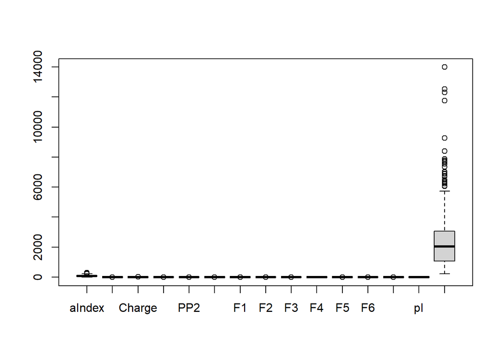

```r
datapep= subset(peptideDescriptors, select = -c(Name, sequence))
view(datapep)
boxplot(datapep)
```

```r
summary(datapep)
```

```
##      aIndex           Boman            Charge             PP1
##  Min.   :  0.00   Min.   :-3.205   Min.   :-7.0470   Min.   :-0.93333
##  1st Qu.: 38.81   1st Qu.: 0.076   1st Qu.:-0.0582   1st Qu.:-0.35587
##  Median : 72.50   Median : 1.393   Median : 1.9400   Median :-0.16502
##  Mean   : 80.56   Mean   : 1.568   Mean   : 2.5539   Mean   :-0.14885
##  3rd Qu.:113.75   3rd Qu.: 2.973   3rd Qu.: 4.9396   3rd Qu.: 0.06288
##  Max.   :292.50   Max.   : 9.578   Max.   :23.9352   Max.   : 0.72200
##       PP2               PP3                 F1                   F2
##  Min.   :-0.8400   Min.   :-0.58083   Min.   :-1.3503333   Min.   :-1.52450
##  1st Qu.:-0.3748   1st Qu.: 0.05558   1st Qu.:-0.3507159   1st Qu.:-0.27754
##  Median :-0.2595   Median : 0.15722   Median :-0.1683089   Median : 0.05994
##  Mean   :-0.2103   Mean   : 0.13123   Mean   :-0.1741883   Mean   : 0.01531
##  3rd Qu.:-0.0737   3rd Qu.: 0.25777   3rd Qu.:-0.0001154   3rd Qu.: 0.34459
##  Max.   : 0.7944   Max.   : 0.72545   Max.   : 0.8100000   Max.   : 1.09789
##        F3                 F4                 F5                  F6
##  Min.   :-1.22467   Min.   :-0.78667   Min.   :-0.677250   Min.   :-1.20275
##  1st Qu.:-0.31215   1st Qu.:-0.05731   1st Qu.:-0.175408   1st Qu.:-0.15448
##  Median :-0.09078   Median : 0.32674   Median :-0.007648   Median : 0.04642
##  Mean   :-0.04197   Mean   : 0.32373   Mean   : 0.112325   Mean   : 0.09522
##  3rd Qu.: 0.23388   3rd Qu.: 0.66357   3rd Qu.: 0.237694   3rd Qu.: 0.33351
##  Max.   : 1.40100   Max.   : 1.39913   Max.   : 2.294667   Max.   : 1.65727
##  Hidrophobicity           pI               MW
##  Min.   :-1.09500   Min.   : 3.167   Min.   :  217.2
##  1st Qu.:-0.13154   1st Qu.: 6.409   1st Qu.: 1066.5
##  Median : 0.04023   Median : 9.700   Median : 2033.5
##  Mean   : 0.07271   Mean   : 9.063   Mean   : 2385.1
##  3rd Qu.: 0.28987   3rd Qu.:11.473   3rd Qu.: 3050.7
##  Max.   : 1.36364   Max.   :13.454   Max.   :13992.9
```

# Los datos no están balanceados, se procede a escalar

```r
pepscale = scale(datapep)
summary(pepscale)
```

```
##      aIndex            Boman              Charge             PP1
##  Min.   :-1.4583   Min.   :-2.31097   Min.   :-2.7657   Min.   :-2.69497
##  1st Qu.:-0.7558   1st Qu.:-0.72243   1st Qu.:-0.7525   1st Qu.:-0.71119
##  Median :-0.1460   Median :-0.08487   Median :-0.1769   Median :-0.05552
##  Mean   : 0.0000   Mean   : 0.00000   Mean   : 0.0000   Mean   : 0.00000
##  3rd Qu.: 0.6007   3rd Qu.: 0.67995   3rd Qu.: 0.6872   3rd Qu.: 0.72739
##  Max.   : 3.8363   Max.   : 3.87818   Max.   : 6.1592   Max.   : 2.99169
##       PP2               PP3                F1                 F2
##  Min.   :-2.5631   Min.   :-3.6346   Min.   :-3.95262   Min.   :-3.43703
##  1st Qu.:-0.6696   1st Qu.:-0.3861   1st Qu.:-0.59325   1st Qu.:-0.65367
##  Median :-0.2005   Median : 0.1327   Median : 0.01976   Median : 0.09963
##  Mean   : 0.0000   Mean   : 0.0000   Mean   : 0.00000   Mean   : 0.00000
##  3rd Qu.: 0.5558   3rd Qu.: 0.6459   3rd Qu.: 0.58500   3rd Qu.: 0.73500
##  Max.   : 4.0891   Max.   : 3.0331   Max.   : 3.30752   Max.   : 2.41645
##        F3                F4                  F5                F6
##  Min.   :-2.9946   Min.   :-2.464961   Min.   :-1.7494   Min.   :-2.8446
##  1st Qu.:-0.6841   1st Qu.:-0.845863   1st Qu.:-0.6375   1st Qu.:-0.5472
##  Median :-0.1236   Median : 0.006682   Median :-0.2658   Median :-0.1069
##  Mean   : 0.0000   Mean   : 0.000000   Mean   : 0.0000   Mean   : 0.0000
##  3rd Qu.: 0.6984   3rd Qu.: 0.754396   3rd Qu.: 0.2778   3rd Qu.: 0.5222
##  Max.   : 3.6536   Max.   : 2.387261   Max.   : 4.8353   Max.   : 3.4233
##  Hidrophobicity           pI                MW
##  Min.   :-3.43180   Min.   :-1.9840   Min.   :-1.1639
##  1st Qu.:-0.60027   1st Qu.:-0.8931   1st Qu.:-0.7079
##  Median :-0.09544   Median : 0.2144   Median :-0.1887
##  Mean   : 0.00000   Mean   : 0.0000   Mean   : 0.0000
##  3rd Qu.: 0.63823   3rd Qu.: 0.8109   3rd Qu.: 0.3574
##  Max.   : 3.79394   Max.   : 1.4776   Max.   : 6.2319
```

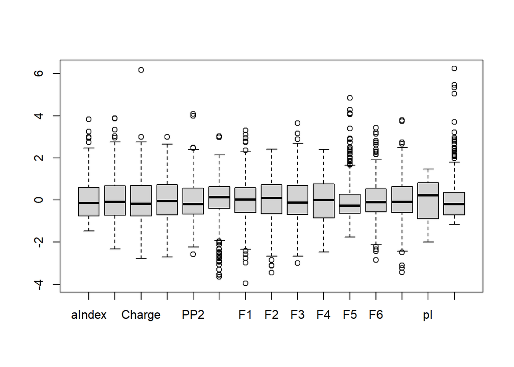

```r
boxplot(pepscale)
```

## Calculo de componentes principales y visualización

```r
PCApep = prcomp(pepscale)
summary(PCApep)
```

```
## Importance of components:
##                           PC1    PC2    PC3     PC4     PC5     PC6     PC7
## Standard deviation     2.3224 1.8596 1.3239 1.18389 1.04345 0.83973 0.56666
## Proportion of Variance 0.3596 0.2305 0.1168 0.09344 0.07259 0.04701 0.02141
## Cumulative Proportion  0.3596 0.5901 0.7069 0.80039 0.87297 0.91998 0.94139
##                            PC8     PC9    PC10    PC11    PC12    PC13    PC14
## Standard deviation     0.51347 0.46029 0.37969 0.33798 0.27539 0.20096 0.14578
## Proportion of Variance 0.01758 0.01412 0.00961 0.00762 0.00506 0.00269 0.00142
## Cumulative Proportion  0.95896 0.97309 0.98270 0.99032 0.99537 0.99806 0.99948
##                           PC15
## Standard deviation     0.08825
## Proportion of Variance 0.00052
## Cumulative Proportion  1.00000
```

## Para escoger el numero de PCAs

```r
stdev= PCApep$sdev
pr_var = stdev^2
pr_var[1:15]
```

```
##  [1] 5.39348202 3.45795200 1.75276269 1.40159609 1.08878225 0.70514448
##  [7] 0.32110338 0.26365175 0.21186363 0.14416178 0.11423220 0.07583927
## [13] 0.04038675 0.02125321 0.00778850
```

```r
prop_varex =pr_var/sum(pr_var)
prop_varex[1:15]
```

```
##  [1] 0.3595654678 0.2305301333 0.1168508457 0.0934397395 0.0725854832
##  [6] 0.0470096321 0.0214068923 0.0175767832 0.0141242420 0.0096107854
## [11] 0.0076154800 0.0050559513 0.0026924498 0.0014168809 0.0005192333
```

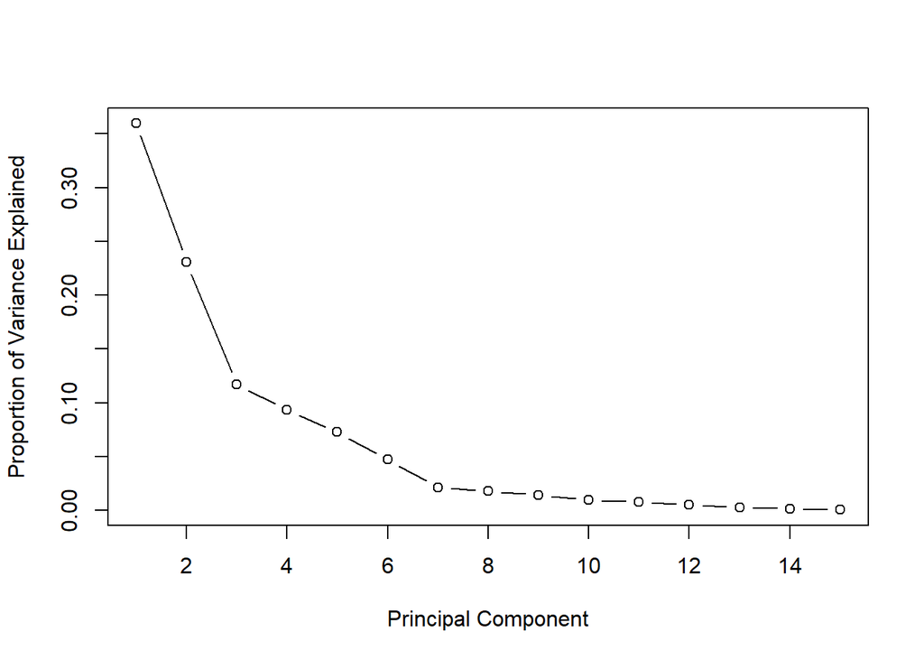

```r
plot(prop_varex, xlab = "Principal Component",ylab = "Proportion of Variance Explained",type = "b")
```

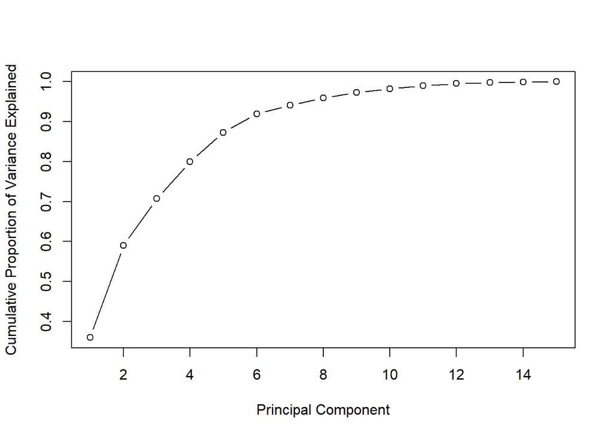

```r
plot(cumsum(prop_varex), xlab = "Principal Component",ylab = "Cumulative Proportion of Variance Explained",type = "b")
```

## Determinar numero optimo de clusters por medio del metodo de “avarage silhouette”

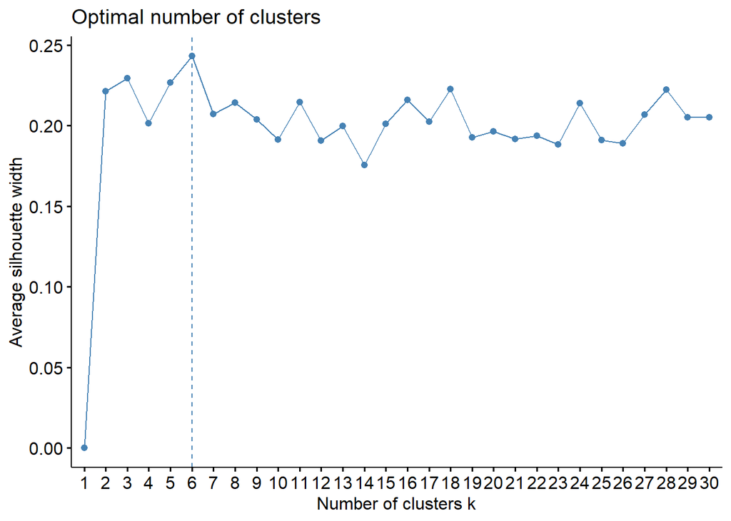

```r
fviz_nbclust(PCApep$x[ ,1:15],kmeans,method = "silhouette", k.max = 30, iter.max=25)
```

## Graficar los datos por medio de heatmap

# Se hacen heatmaps desde 3 clusters hasta 11 clusters

# Heatmap de 3 clusters

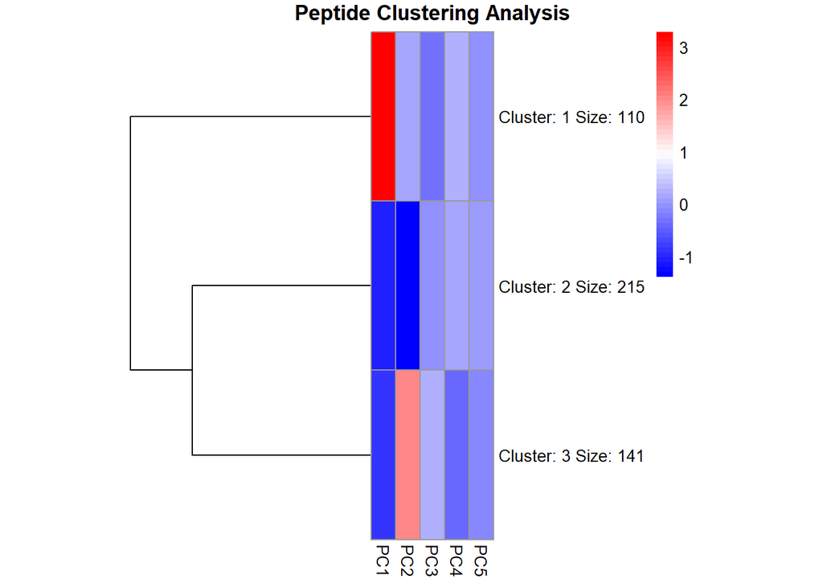

```r
cluster3pep= pheatmap(PCApep$x[,1:5], kmeans_k = 3,cluster_cols = FALSE, treeheight_row = 150, cellwidth = 15, color = colorRampPalette(c("blue", "white", "red"))(50),main = "Peptide Clustering Analysis" )
```

```r
write.csv2 (cluster3pep$kmeans$cluster, file="clustermember3pep.csv")
```

# Heatmap de 4 clusters

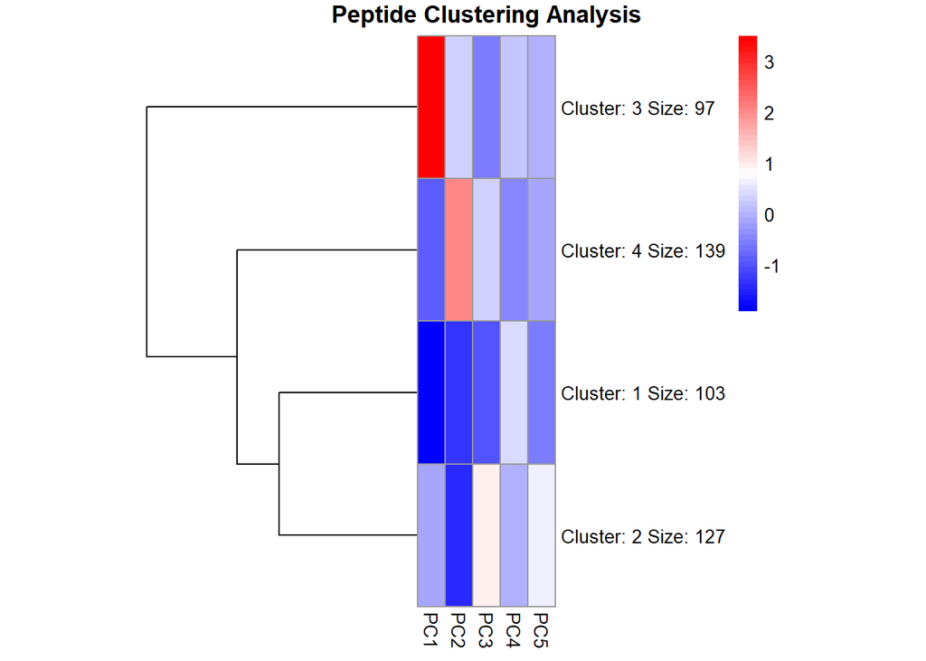

```r
cluster4pep= pheatmap(PCApep$x[,1:5], kmeans_k = 4,cluster_cols = FALSE, treeheight_row = 150, cellwidth = 15, color = colorRampPalette(c("blue", "white", "red"))(50),main = "Peptide Clustering Analysis" )
```

```r
write.csv2 (cluster4pep$kmeans$cluster, file="clustermember4pep.csv")
```

# Heatmap de 5 clusters

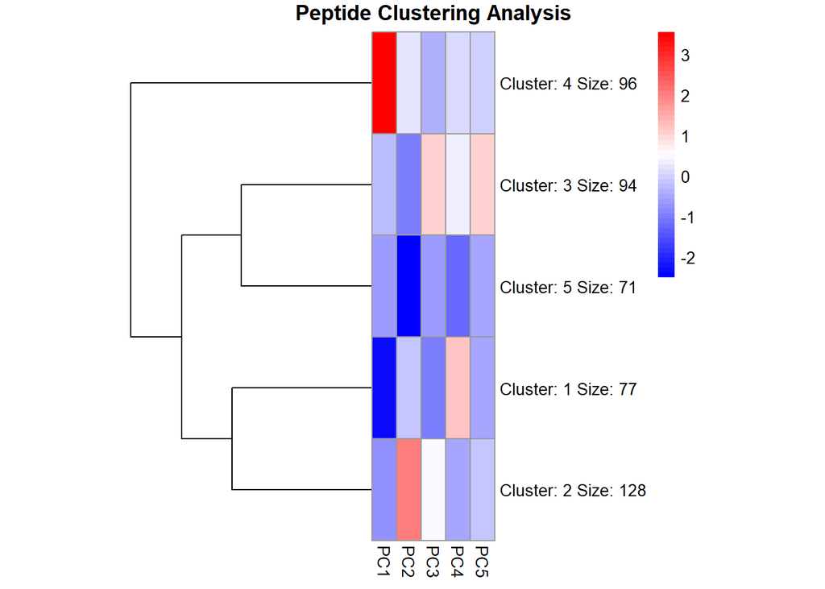

```r
cluster5pep= pheatmap(PCApep$x[,1:5], kmeans_k = 5,cluster_cols = FALSE, treeheight_row = 150, cellwidth = 15, color = colorRampPalette(c("blue", "white", "red"))(50),main = "Peptide Clustering Analysis" )
```

```r
write.csv2 (cluster5pep$kmeans$cluster, file="clustermember5pep.csv")
```

# Heatmap de 6 clusters

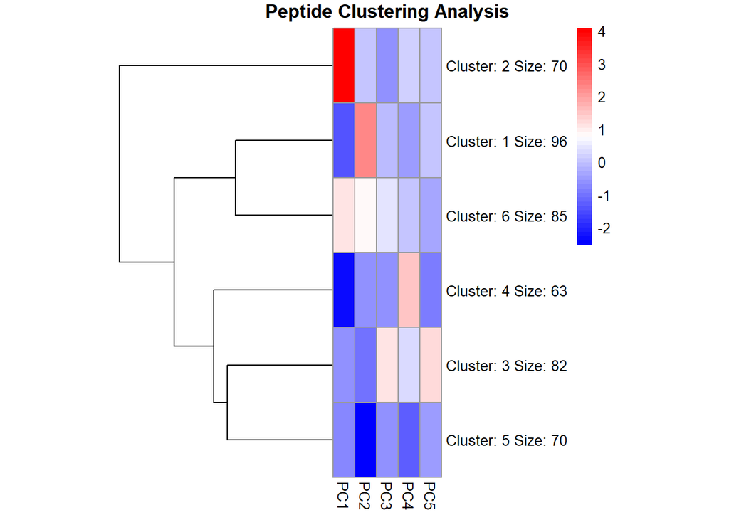

```r
cluster6pep= pheatmap(PCApep$x[,1:5], kmeans_k = 6,cluster_cols = FALSE, treeheight_row = 150, cellwidth = 15, color = colorRampPalette(c("blue", "white", "red"))(50),main = "Peptide Clustering Analysis" )
```

```r
write.csv2 (cluster6pep$kmeans$cluster, file="clustermember6pep.csv")
```

# Heatmap de 7 clusters

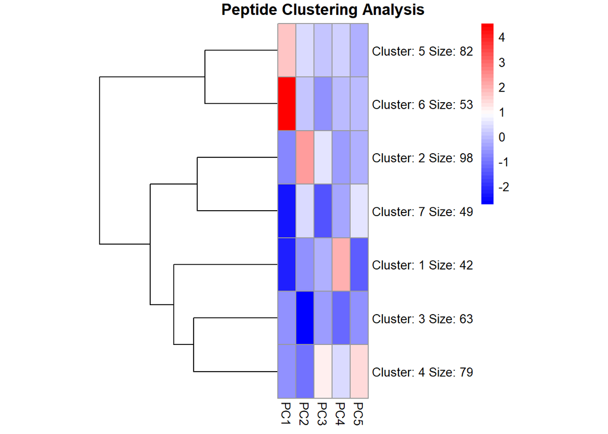

```r
cluster7pep= pheatmap(PCApep$x[,1:5], kmeans_k = 7,cluster_cols = FALSE, treeheight_row = 150, cellwidth = 15, color = colorRampPalette(c("blue", "white", "red"))(50),main = "Peptide Clustering Analysis" )
```

```r
write.csv2 (cluster7pep$kmeans$cluster, file="clustermember7pep.csv")
```

# Heatmap de 8 clusters

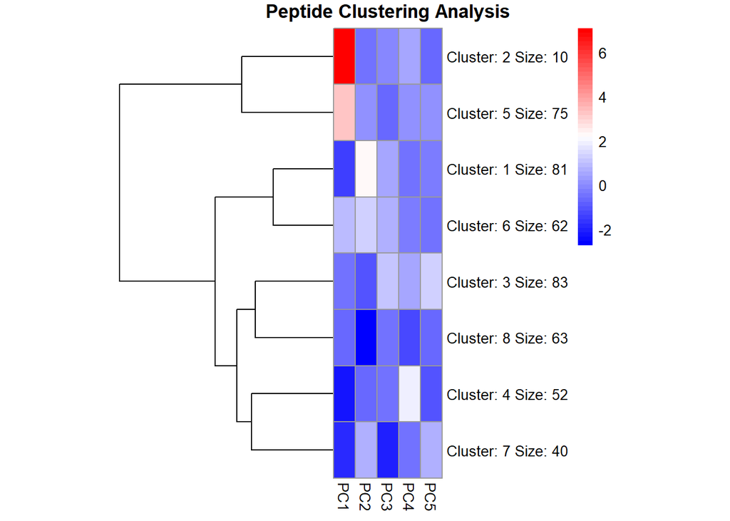

```r
cluster8pep= pheatmap(PCApep$x[,1:5], kmeans_k = 8,cluster_cols = FALSE, treeheight_row = 150, cellwidth = 15, color = colorRampPalette(c("blue", "white", "red"))(50),main = "Peptide Clustering Analysis" )
```

```r
write.csv2 (cluster8pep$kmeans$cluster, file="clustermember8pep.csv")
```

# Heatmap de 9 clusters

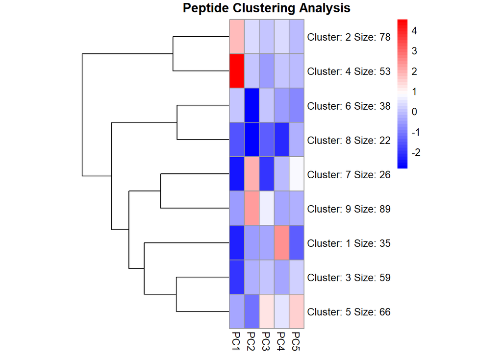

```r
cluster9pep= pheatmap(PCApep$x[,1:5], kmeans_k = 9,cluster_cols = FALSE, treeheight_row = 150, cellwidth = 15, color = colorRampPalette(c("blue", "white", "red"))(50),main = "Peptide Clustering Analysis" )
```

```r
write.csv2 (cluster9pep$kmeans$cluster, file="clustermember9pep.csv")
```

# Heatmap de 10 clusters

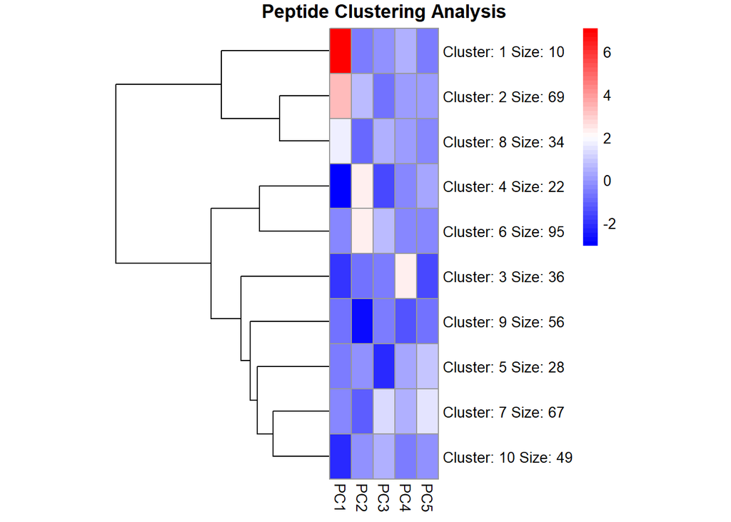

```r
cluster10pep= pheatmap(PCApep$x[,1:5], kmeans_k = 10,cluster_cols = FALSE, treeheight_row = 150, cellwidth = 15, color = colorRampPalette(c("blue", "white", "red"))(50),main = "Peptide Clustering Analysis" )
```

```r
write.csv2 (cluster10pep$kmeans$cluster, file="clustermember10pep.csv")
```

# Heatmap de 11 clusters

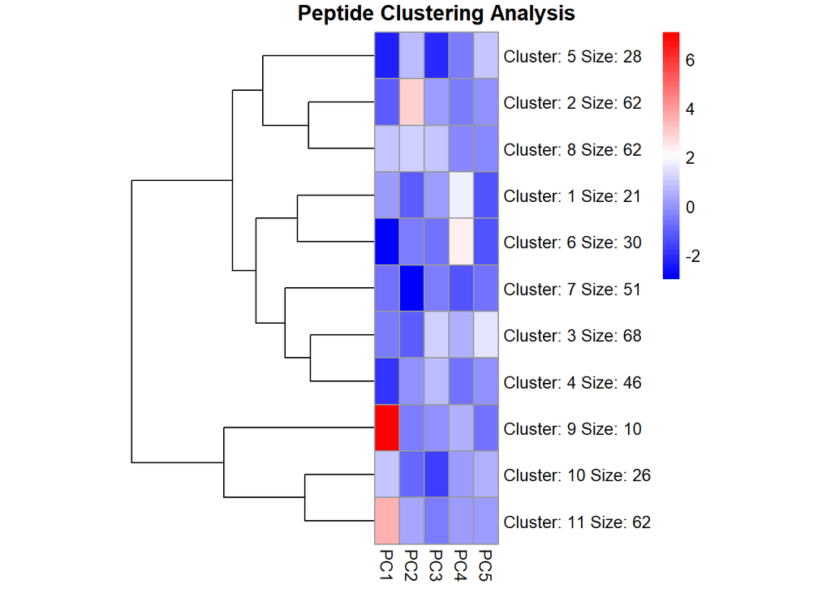

```r
cluster11pep= pheatmap(PCApep$x[,1:5], kmeans_k = 11,cluster_cols = FALSE, treeheight_row = 150, cellwidth = 15, color = colorRampPalette(c("blue", "white", "red"))(50),main = "Peptide Clustering Analysis" )
```

```r
write.csv2 (cluster11pep$kmeans$cluster, file="clustermember11pep.csv")
```

## Análisis de resultados tomados del heatmap de 11 clusters

El primer set de resultados mostró que la mayor concentración de CSP-EX se encuentran en el cluster 7, junto con 27% de los péptidos antioxidantes lo que puede indicar que estos péptidos pueden tener potencial antioxidante.

En el cluster 7 el componente principal 2 es el predominante, los descriptores más sobresalientes son los vectores de Fasgai relacionados con los índices alifático y de hidrofobicidad y el punto isoeléctrico. Lo que significa que este cluster puede estar definido por la interacción con hidrógeno. Cluster 4 tiene 51% de los péptidos con actividad anticongelante, los péptidos CSP-EX en este cluster pueden tener potencial como péptidos anticongelantes.

Cabe resaltar que los péptidos penetrantes de células (CPP) no mostraron una agrupación muy fuerte con los CSP-EX.

## Análisis de Datos y componentes principales obtenidos

# Importar y explorar archivo “Descriptores”, generado de los datos obtenidos anteriormente

```r
Descriptores <- read_excel("Descriptores.xlsx")
View(Descriptores)

# cambiar algunos valores a factor
Descriptores$Name <- as.factor(Descriptores$Name)
Descriptores$Tipo <- as.factor(Descriptores$Tipo)
str(Descriptores)
```

```
## tibble [466 × 19] (S3: tbl_df/tbl/data.frame)
##  $ ...1          : num [1:466] 1 2 3 4 5 6 7 8 9 10 ...
##  $ Name          : Factor w/ 466 levels ">AFP_1",">AFP_10",..: 28 94 102 122 137 143 36 49 57 67 ...
##  $ sequence      : chr [1:466] "AAVPSGASTGIYEALELR" "ACSNHSPLGWRGH" "AEEEYPD" "AKYIPIQYVLSRYPSY" ...
##  $ Tipo          : Factor w/ 7 levels "AFP","Antiox",..: 2 2 2 2 2 2 2 2 2 2 ...
##  $ aIndex        : num [1:466] 103.3 37.7 14.3 97.5 20 ...
##  $ Boman         : num [1:466] 0.563 1.958 3.926 0.797 2.696 ...
##  $ Charge        : num [1:466] -1.054 1.332 -4.05 1.936 0.342 ...
##  $ PP1           : num [1:466] -0.33 -0.0877 0.3371 -0.1325 0.238 ...
##  $ PP2           : num [1:466] -0.4539 -0.3385 -0.4643 -0.0994 -0.488 ...
##  $ PP3           : num [1:466] 0.0928 0.2762 -0.5614 0.0862 0.398 ...
##  $ F1            : num [1:466] -0.1121 -0.1028 -0.7451 -0.0538 -0.172 ...
##  $ F2            : num [1:466] 0.0165 -0.4549 0.235 -0.2691 0.0892 ...
##  $ F3            : num [1:466] -0.383 -0.435 -0.212 0.364 -0.549 ...
##  $ F4            : num [1:466] 0.8094 -0.0149 0.1777 0.2704 -0.1008 ...
##  $ F5            : num [1:466] 0.148 0.00677 0.584 0.25881 0.0434 ...
##  $ F6            : num [1:466] -0.2092 -0.1303 -1.0129 0.2653 0.0494 ...
##  $ Hidrophobicity: num [1:466] -0.0222 -0.0754 0.3914 -0.0963 0.268 ...
##  $ pI            : num [1:466] 4.26 8.56 3.33 9.63 7.71 ...
##  $ MW            : num [1:466] 1805 1422 852 1961 552 ...
```

## Grafica de correlación, los datos son divididos para ver mejor la grafica, pero son usados todos juntos en la matris de correlación

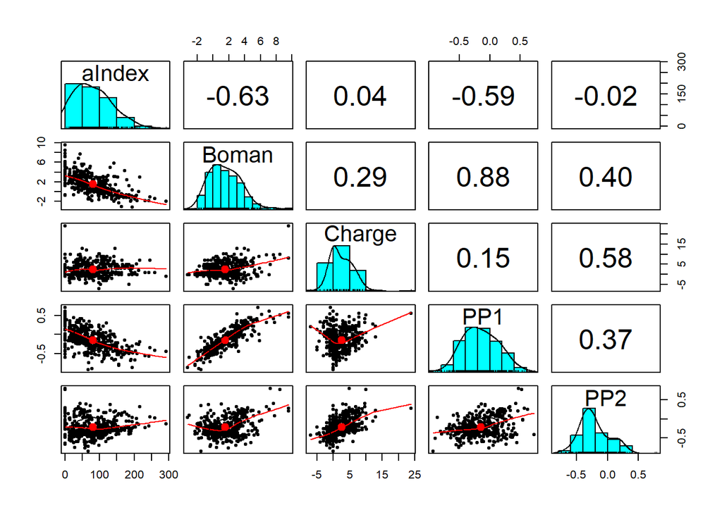

```r
pairs.panels(Descriptores[5:9])
```

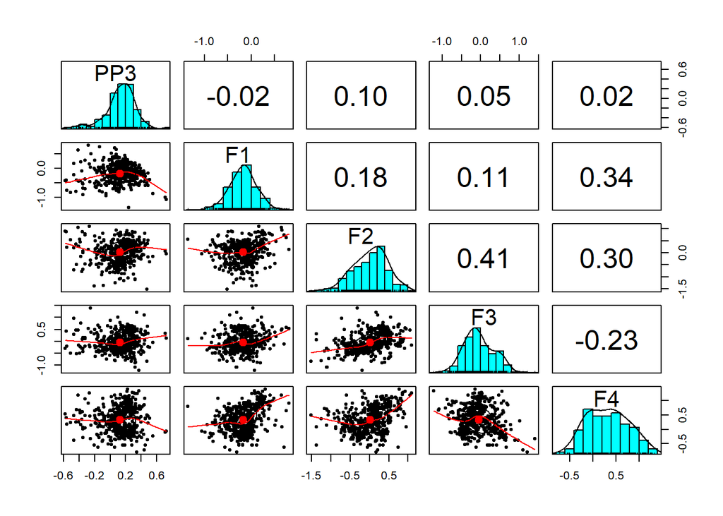

```r
pairs.panels(Descriptores[10:14])
```

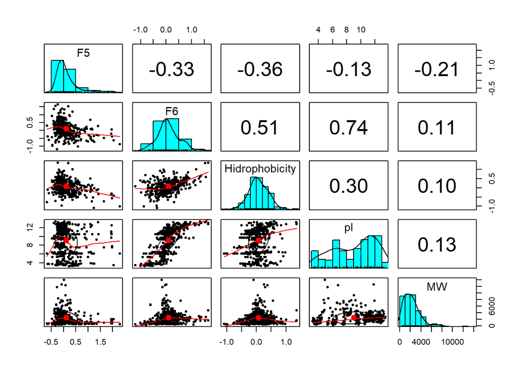

```r
pairs.panels(Descriptores[15:19])
```

```r
DescriptoresCor<-cor(Descriptores[5:19], method = "pearson")
DescriptoresCor
```

```
##                     aIndex       Boman      Charge         PP1         PP2
## aIndex          1.00000000 -0.63424983  0.03964508 -0.59008757 -0.01538146
## Boman          -0.63424983  1.00000000  0.29478238  0.87710305  0.39543574
## Charge          0.03964508  0.29478238  1.00000000  0.15275530  0.57598459
## PP1            -0.59008757  0.87710305  0.15275530  1.00000000  0.36835364
## PP2            -0.01538146  0.39543574  0.57598459  0.36835364  1.00000000
## PP3            -0.04194172  0.24426391  0.72819192  0.03194571  0.28945284
## F1              0.50257400 -0.63413303 -0.03005140 -0.58226077  0.05484521
## F2              0.51515236 -0.02403108  0.26727877  0.09810552  0.33614013
## F3              0.15630353  0.21000815  0.42061741  0.30345046  0.93036679
## F4              0.76435245 -0.62590952 -0.06064807 -0.65609233 -0.38366967
## F5              0.06774276 -0.19537344 -0.24816290 -0.35280510 -0.11579794
## F6             -0.01863411  0.50650754  0.73187305  0.39286036  0.76187271
## Hidrophobicity -0.38279792  0.83170030  0.38488362  0.78016019  0.21625053
## pI              0.13911597  0.21391926  0.84033166  0.04271785  0.61010007
## MW             -0.07234961  0.04850901  0.23475542  0.03880881 -0.10017174
##                        PP3          F1           F2          F3          F4
## aIndex         -0.04194172  0.50257400  0.515152364  0.15630353  0.76435245
## Boman           0.24426391 -0.63413303 -0.024031082  0.21000815 -0.62590952
## Charge          0.72819192 -0.03005140  0.267278770  0.42061741 -0.06064807
## PP1             0.03194571 -0.58226077  0.098105520  0.30345046 -0.65609233
## PP2             0.28945284  0.05484521  0.336140129  0.93036679 -0.38366967
## PP3             1.00000000 -0.01784492  0.103858345  0.05145631  0.02051235
## F1             -0.01784492  1.00000000  0.182042182  0.11132657  0.34004452
## F2              0.10385835  0.18204218  1.000000000  0.40967819  0.30266734
## F3              0.05145631  0.11132657  0.409678191  1.00000000 -0.23410563
## F4              0.02051235  0.34004452  0.302667340 -0.23410563  1.00000000
## F5             -0.27349735 -0.03284154 -0.336981307 -0.10560701  0.10030564
## F6              0.67915146 -0.14628232  0.352733220  0.60253568 -0.31348875
## Hidrophobicity  0.38315327 -0.69790014  0.252897949  0.09464206 -0.26674603
## pI              0.75186317  0.03885569  0.289365871  0.46416175  0.02015822
## MW              0.19508237  0.00733262 -0.009643591 -0.18220143 -0.08672962
##                         F5          F6 Hidrophobicity          pI           MW
## aIndex          0.06774276 -0.01863411    -0.38279792  0.13911597 -0.072349606
## Boman          -0.19537344  0.50650754     0.83170030  0.21391926  0.048509006
## Charge         -0.24816290  0.73187305     0.38488362  0.84033166  0.234755424
## PP1            -0.35280510  0.39286036     0.78016019  0.04271785  0.038808810
## PP2            -0.11579794  0.76187271     0.21625053  0.61010007 -0.100171742
## PP3            -0.27349735  0.67915146     0.38315327  0.75186317  0.195082373
## F1             -0.03284154 -0.14628232    -0.69790014  0.03885569  0.007332620
## F2             -0.33698131  0.35273322     0.25289795  0.28936587 -0.009643591
## F3             -0.10560701  0.60253568     0.09464206  0.46416175 -0.182201431
## F4              0.10030564 -0.31348875    -0.26674603  0.02015822 -0.086729624
## F5              1.00000000 -0.33154869    -0.36375237 -0.13038116 -0.211033738
## F6             -0.33154869  1.00000000     0.51321787  0.73606296  0.110767424
## Hidrophobicity -0.36375237  0.51321787     1.00000000  0.30475983  0.099875457
## pI             -0.13038116  0.73606296     0.30475983  1.00000000  0.125316948
## MW             -0.21103374  0.11076742     0.09987546  0.12531695  1.000000000
```

## Análisis de componentes principales y obtencion de la varianza

```r
DescriptoresDF <- as.data.frame(Descriptores[,5:19])
row.names(DescriptoresDF) <- Descriptores$Name
head(DescriptoresDF)
```

```
##              aIndex     Boman     Charge         PP1        PP2         PP3
## >Antiox_1 103.33333 0.5627778 -1.0538969 -0.33000000 -0.4538889  0.09277778
## >Antiox_2  37.69231 1.9584615  1.3324165 -0.08769231 -0.3384615  0.27615385
## >Antiox_3  14.28571 3.9257143 -4.0497356  0.33714286 -0.4642857 -0.56142857
## >Antiox_6  97.50000 0.7975000  1.9364036 -0.13250000 -0.0993750  0.08625000
## >Antiox_8  20.00000 2.6960000  0.3423275  0.23800000 -0.4880000  0.39800000
## >Antiox_9  55.71429 2.1071429  0.9397985 -0.24142857 -0.1771429  0.06285714
##                   F1         F2          F3          F4          F5         F6
## >Antiox_1 -0.1120556  0.0165000 -0.38272222  0.80944444 0.148000000 -0.2091667
## >Antiox_2 -0.1028462 -0.4549231 -0.43461538 -0.01492308 0.006769231 -0.1303077
## >Antiox_3 -0.7451429  0.2350000 -0.21242857  0.17771429 0.584000000 -1.0128571
## >Antiox_6 -0.0538125 -0.2690625  0.36400000  0.27043750 0.258812500  0.2653125
## >Antiox_8 -0.1720000  0.0892000 -0.54920000 -0.10080000 0.043400000  0.0494000
## >Antiox_9 -0.5312857 -0.4012857  0.01671429  0.12785714 0.943000000  0.2348571
##           Hidrophobicity       pI        MW
## >Antiox_1    -0.02222222 4.258141 1805.0177
## >Antiox_2    -0.07538462 8.564801 1421.5558
## >Antiox_3     0.39142857 3.331708  851.8218
## >Antiox_6    -0.09625000 9.634027 1961.2909
## >Antiox_8     0.26800000 7.714355  551.5595
## >Antiox_9     0.03428571 9.348818  829.9542
```

```r
# Usando PCApep anterior

get_eigenvalue(PCApep)
```

```
##        eigenvalue variance.percent cumulative.variance.percent
## Dim.1  5.39348202      35.95654678                    35.95655
## Dim.2  3.45795200      23.05301333                    59.00956
## Dim.3  1.75276269      11.68508457                    70.69464
## Dim.4  1.40159609       9.34397395                    80.03862
## Dim.5  1.08878225       7.25854832                    87.29717
## Dim.6  0.70514448       4.70096321                    91.99813
## Dim.7  0.32110338       2.14068923                    94.13882
## Dim.8  0.26365175       1.75767832                    95.89650
## Dim.9  0.21186363       1.41242420                    97.30892
## Dim.10 0.14416178       0.96107854                    98.27000
## Dim.11 0.11423220       0.76154800                    99.03155
## Dim.12 0.07583927       0.50559513                    99.53714
## Dim.13 0.04038675       0.26924498                    99.80639
## Dim.14 0.02125321       0.14168809                    99.94808
## Dim.15 0.00778850       0.05192333                   100.00000
```

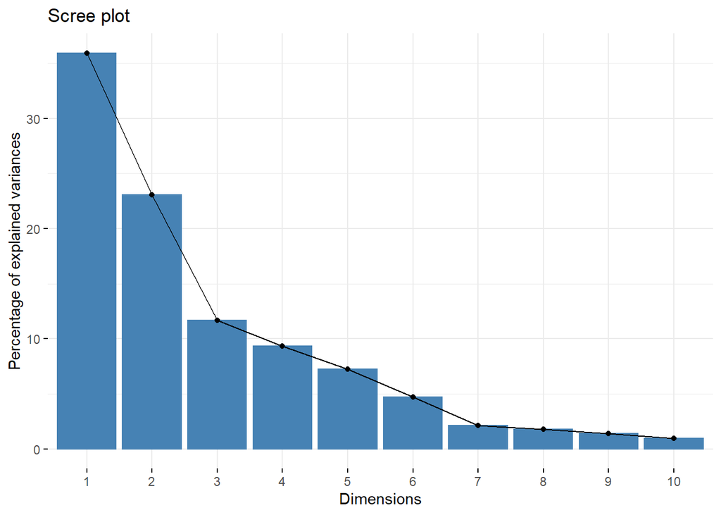

```r
fviz_eig(PCApep)
```

```r
fviz_pca
```

```
## function (X, ...)
## {
##     fviz_pca_biplot(X, ...)
## }
## <bytecode: 0x000001916f372c60>
## <environment: namespace:factoextra>
```

## Graficas de distribución con y sin elipses

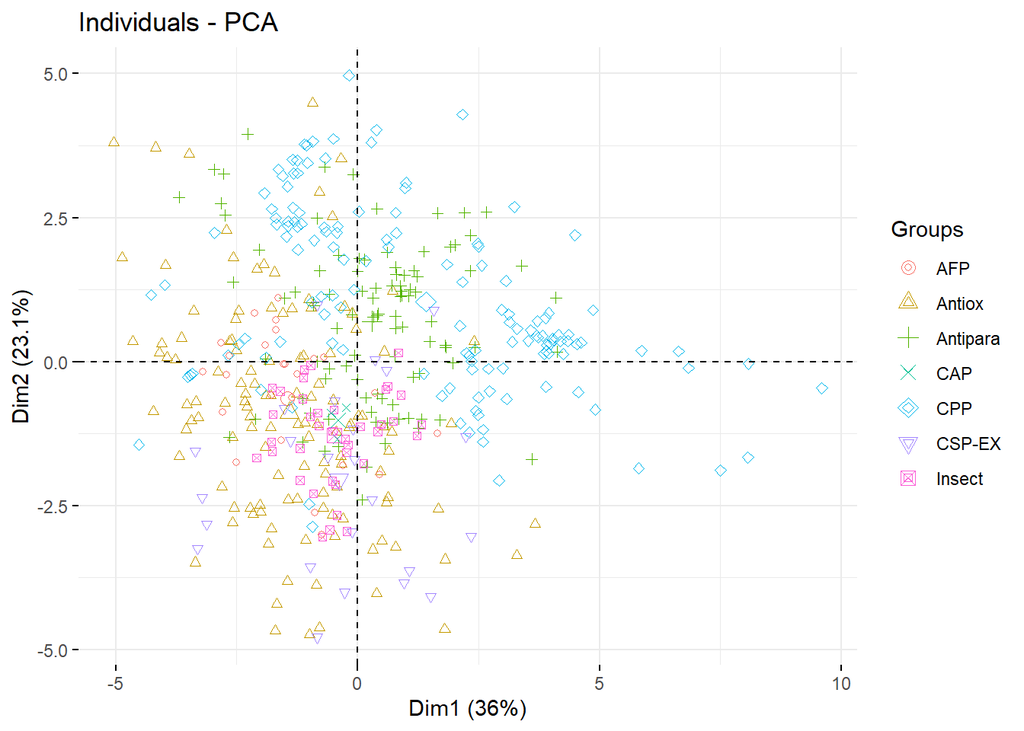

```r
fviz_pca_ind(PCApep, repel = TRUE,
             label = "none",
             habillage = Descriptores$Tipo)
```

```
## Too few points to calculate an ellipse
```

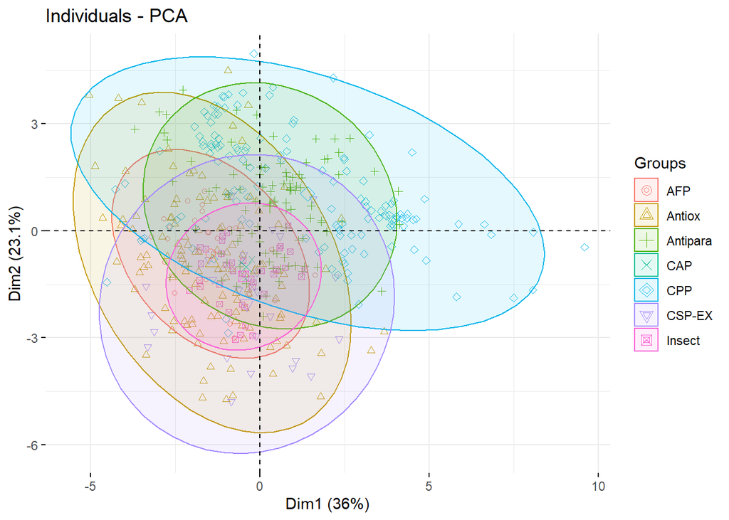

```r
fviz_pca_ind(PCApep, repel = TRUE,
             label = "none",
             habillage = Descriptores$Tipo,
             addEllipses = TRUE)
```

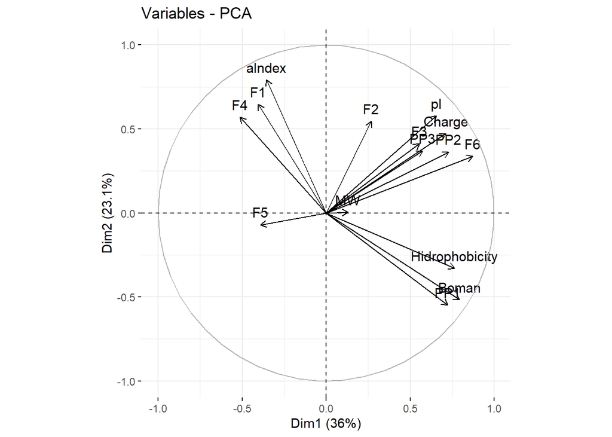

```r
fviz_pca_var(PCApep)
```

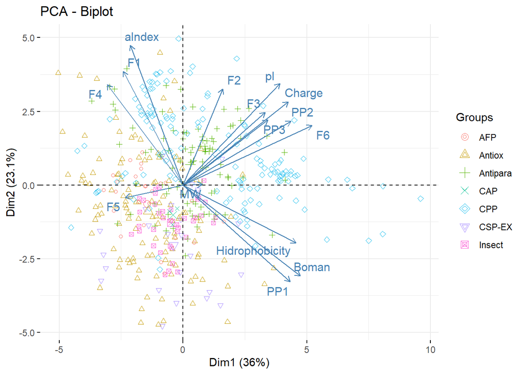

```r
# Ambos

fviz_pca_biplot(PCApep,
                repel = TRUE,
                label = "var",
                habillage = Descriptores$Tipo)
```